# Проект ANOVA

Литвинов Даниил

05/02/2021

```r
library(ggplot2)
library(dplyr)
library(car)
library(Hmisc)
library(multcomp)
library(gridExtra)
library(gridExtra)
library(readxl)
theme_set(theme_bw())
```

# 1 Введение

В данной работе используются данные, которые были собраны двадцатью врачами. Основной акцент был сделан на применение дисперсионного анализа.

Цель – как различные факторы (пол и тип лекарства) влияют на длительность нахождения человека в госпитале.

# 2 Описание данных

## 2.1 Приведение данных в порядок (tidydata)

Так как данные находятся в разных файлах формата csv, их необходимо объединить для дальнейшего анализа. Для этого я написал следующую пользовательскую функцию, которая на вход принимает путь до файлов и их расширение, а возвращает датафрейм, который включает в себя все данные, а также единый файл того формата, который был передан на вход.

```r
data_join <- function(directory, extension = 'csv'){

  # Именованный вектор с функциями для чтения файлов с различными расширениями
  functions <- c(csv = read.csv,
                 tsv = read.delim,
                 csv2 = read.csv2,
                 xls = read_excel,
                 xlsx = read_excel,
                 .csv = read.csv,
                 .tsv = read.delim,
                 .csv2 = read.csv2,
                 .xls = read_excel,
                 .xlsx = read_excel)

  df <- data.frame()
  for (file in list.files(directory)){
    if (endsWith(file, suffix = extension)){
      data <- functions[extension][[1]](paste0(directory, file))
      df <- rbind(df, data)
    }
  }

  # Сортируем по порядку названий файлов (переменная X)
  # Удаляем ее из итоговой таблицы
  df <- arrange(df, colnames(df)[1])[, -1]

  # В задании написано также объединить файлы в один файл, пусть будет так)
  if (!dir.exists(paste0(directory, 'full_out/'))){
    dir.create(paste0(directory, 'full_out/'))
  }
  if (startsWith(extension, prefix = '.')){
    write.csv(df, paste0(directory, 'full_out/whole_data', extension))
  }
  else {
    write.csv(df, paste0(directory, 'full_out/whole_data.', extension))
  }

  return(df)
}
```

Считываем данные и сразу проверяем, все ли открылось правильно:

```r
drug_data <- data_join('/home/danil/bioinf_institute/statistics/Homework/Project_ad_ANOVA/Data/')
str(drug_data)
```

```
## 'data.frame':    200 obs. of  6 variables:
##  $ gender          : chr  "female" "female" "female" "female" ...
##  $ age             : chr  "26" "26" "31" "28" ...
##  $ drug_type       : chr  "Placebo" "Placebo" "Placebo" "Placebo" ...
##  $ is_relapse      : int  0 1 0 1 1 NA 0 1 1 0 ...
##  $ id              : int  101 102 103 104 105 106 107 108 109 110 ...
##  $ days_in_hospital: num  25.2 23.3 29.9 27.8 23.3 ...
```

```r
dim(drug_data)
```

```
## [1] 200   6
```

Видим, что у нас 200 наблюдений и 6 переменных, из которых наибольший интерес для нас представляет целевая переменная days_in_hospital и две факторные переменные gender и drug_type.

Проверим данные на наличие пропущенных значений:

```r
apply(apply(drug_data, 2, is.na), 2, sum)
```

```
##           gender              age        drug_type       is_relapse
##                0                0                0               10
##               id days_in_hospital
##                0                0
```

Видим, что есть 10 отсутствующих значений в одной переменной, которая отражает наличие рецидива. Я решил заменить все NA на нули, так как, скорее всего, если рецидива и правда не было, врач мог просто забыть написать о его отсутствии. А выкидывать 5 % данных при таком небольшом числе наблюдений не хочется.

```r
drug_data$is_relapse[is.na(drug_data$is_relapse)] <-  0
```

```r
apply(drug_data[, -5], 2, unique)
```

```
## $gender
## [1] "female" "male"   "malle"
##
## $age
##  [1] "26"         "31"         "28"         "29"         "30"
##  [6] "36"         "24"         "37"         "27"         "32"
## [11] "33"         "25"         "35"         "34"         "thirty-one"
## [16] "350"        "220"        "23"
##
## $drug_type
## [1] "Placebo"    "New_type_2" "New_type_1" "Old_type"
##
## $is_relapse
## [1] "0" "1"
##
```

[output cut: 35 more lines]

Видим несколько ошибок при сборе данных (malle, 350 лет, возраст, написанный словами и тд). Сразу же исправляем их.

```r
drug_data$gender[drug_data$gender == 'malle'] <- 'male'
drug_data$gender <- as.factor(drug_data$gender)
drug_data$age[drug_data$age == 'thirty-one'] <- 31
drug_data$age[drug_data$age == '350'] <- 35
drug_data$age[drug_data$age == '220'] <- 22
drug_data$age <- as.integer(drug_data$age)
drug_data$drug_type <- as.factor(drug_data$drug_type)
drug_data$is_relapse <- as.factor(drug_data$is_relapse)
drug_data$days_in_hospital <- as.numeric(drug_data$days_in_hospital)
```

Также добавим сразу новую переменную condition, которая будет являться результатом конкатенации значений переменной gender и drug_type.

```r
drug_data$сondition <- as.factor(paste(drug_data$gender, drug_data$drug_type, sep = '_'))
```

Вроде бы, мы ничего не испортили, данные выглядят хорошо. Можно приступать к EDA.

```r
dim(drug_data)
```

```
## [1] 200   7
```

```r
str(drug_data)
```

```
## 'data.frame':    200 obs. of  7 variables:
##  $ gender          : Factor w/ 2 levels "female","male": 1 1 1 1 1 1 1 1 1 1 ...
##  $ age             : int  26 26 31 28 29 30 36 31 31 30 ...
##  $ drug_type       : Factor w/ 4 levels "New_type_1","New_type_2",..: 4 4 4 4 4 4 4 4 4 4 ...
##  $ is_relapse      : Factor w/ 2 levels "0","1": 1 2 1 2 2 1 1 2 2 1 ...
##  $ id              : int  101 102 103 104 105 106 107 108 109 110 ...
##  $ days_in_hospital: num  25.2 23.3 29.9 27.8 23.3 ...
##  $ сondition       : Factor w/ 8 levels "female_New_type_1",..: 4 4 4 4 4 4 4 4 4 4 ...
```

```r
head(drug_data)
```

```
##   gender age drug_type is_relapse  id days_in_hospital      сondition
## 1 female  26   Placebo          0 101         25.18238 female_Placebo
## 2 female  26   Placebo          1 102         23.26929 female_Placebo
## 3 female  31   Placebo          0 103         29.86716 female_Placebo
## 4 female  28   Placebo          1 104         27.82082 female_Placebo
## 5 female  29   Placebo          1 105         23.27875 female_Placebo
## 6 female  30   Placebo          0 106         24.66779 female_Placebo
```

## 2.2 EDA

Построим несколько графиков, чтобы посмотреть, как распределена переменная days_in_hospital в различных группах. Видно, что в данном случае наши группы имеют не одинаковое число наблюдений. Для нас это не критично, так как мы планируем исследовать лишь группы, которые определяются полом и типом лекарства.

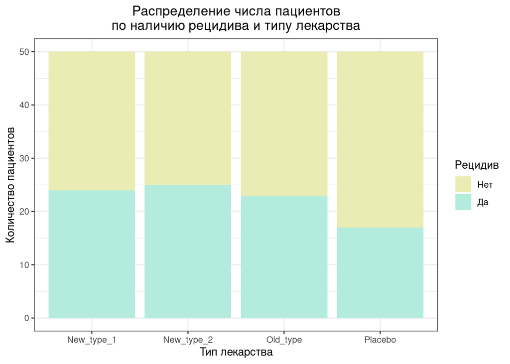

```r
ggplot(drug_data, aes(drug_type, fill = is_relapse)) +
  geom_bar() +
  ggtitle('Распределение числа пациентов\nпо наличию рецидива и типу лекарства') +
  scale_fill_manual(values = c('0' = '#EBECB3',
                               '1' = '#B3ECDD'),
                    name = "Рецидив", labels = c('Нет', 'Да')) +
  theme(plot.title = element_text(hjust = 0.5)) +
  xlab('Тип лекарства') +
  ylab('Количество пациентов')
```

Здесь видим полностью сбалансированные группы. Дисперсионный анализ в данном случае должен вести себя хорошо и быть устойчивым к некоторым нарушениям применимости, если таковые будут наблюдаться.

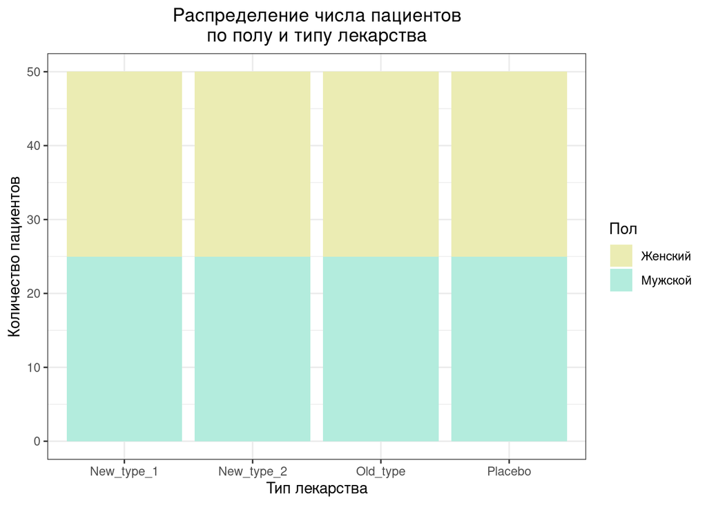

```r
ggplot(drug_data, aes(drug_type, fill = gender)) +
  geom_bar() +
  ggtitle('Распределение числа пациентов\nпо полу и типу лекарства') +
  scale_fill_manual(values = c('female' = '#EBECB3',
                               'male' = '#B3ECDD'),
                    name = "Пол", labels = c('Женский', 'Мужской')) +
  theme(plot.title = element_text(hjust = 0.5)) +
  xlab('Тип лекарства') +
  ylab('Количество пациентов')
```

Эти данные уже сейчас могут навести на мысли о том, что лекарства действуют по-разному в зависимости от пола пациента. Чтобы это подтвердить, необходимо будет провести двухфакторный дисперсионный анализ.

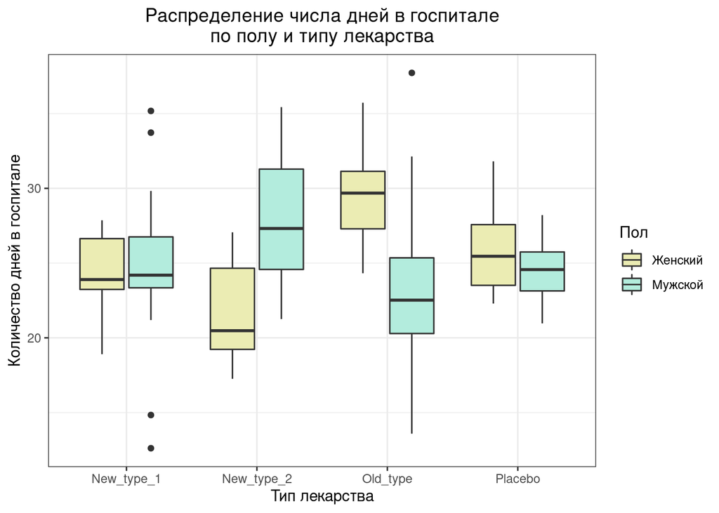

```r
ggplot(drug_data, aes(x = drug_type, y = days_in_hospital)) +
  geom_boxplot(aes(fill = gender)) +
  scale_fill_manual(values = c('female' = '#EBECB3',
                               'male' = '#B3ECDD'),
                    name = "Пол", labels = c('Женский', 'Мужской')) +
  theme(plot.title = element_text(hjust = 0.5)) +
  xlab('Тип лекарства') +
  ylab('Количество дней в госпитале') +
  ggtitle('Распределение числа дней в госпитале\nпо полу и типу лекарства')
```

# 3 Дисперсионный анализ

## 3.1 Построение модели

Построим линейную модель по факторам gender и drug_type и проведем двухвакторный дисперсионный анализ (ANOVA).

```r
hosp_duration_mod <- lm(days_in_hospital ~ gender + drug_type, data = drug_data)
av_hosp_duration_mod <- Anova(mod = hosp_duration_mod)
av_hosp_duration_mod
```

```
## Anova Table (Type II tests)
##
## Response: days_in_hospital
##           Sum Sq  Df F value Pr(>F)
## gender       7.1   1   0.404 0.5258
## drug_type   89.0   3   1.696 0.1692
## Residuals 3409.7 195
```

Видим, что в случае модели без взаимодействия предикторов никакой из них значимо не влияет на значение целевой переменной.

Также интересно посмотреть на различные типы изменчивости в наших данных.

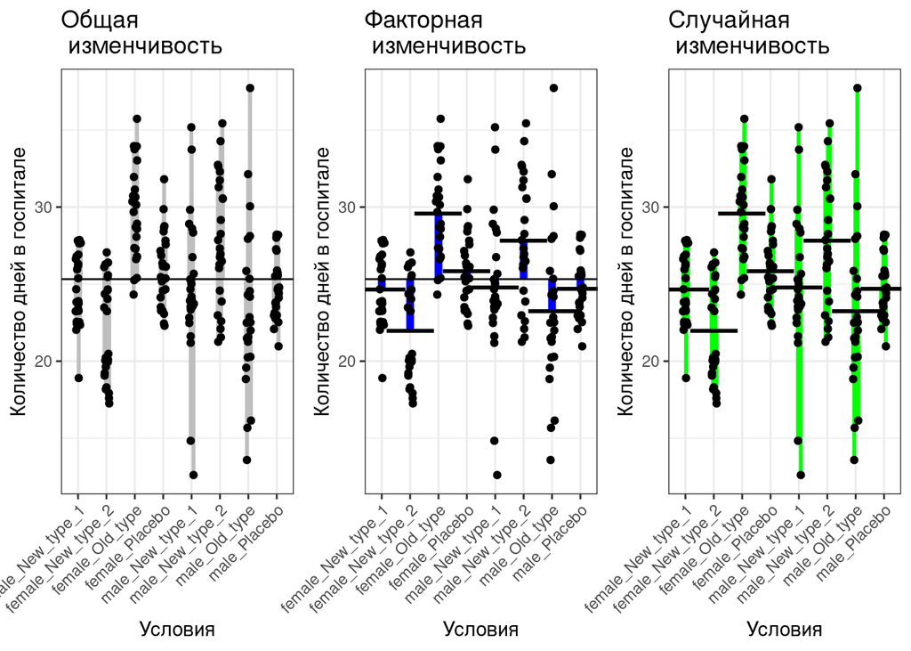

```r
total <- ggplot(data = drug_data, aes(x = сondition, y = days_in_hospital)) +
  geom_linerange(data = drug_data, aes(x = сondition,
                     ymax = days_in_hospital,
                     ymin = mean(drug_data$days_in_hospital)),
                 size = 1,color = "grey",
                 position = position_jitter(width = 0.1,
                                            seed = 1L)) +
  geom_hline(yintercept = mean(drug_data$days_in_hospital)) +
  geom_point(position = position_jitter(width = 0.1, seed = 1L)) +
  ggtitle("Общая \n изменчивость") +
  theme(axis.text.x = element_text(angle = 45, hjust = 1)) +
  xlab('Условия') +
  ylab('Количество дней в госпитале')



gr_mean <- drug_data %>%
           group_by(сondition) %>%
           summarise(mean = mean(days_in_hospital))

two_pic <-right_join(x = drug_data, y = gr_mean)
hline <- data.frame(Cond = levels(drug_data$сondition), v = gr_mean$mean)

resid <- ggplot(two_pic, aes(x = сondition, y = days_in_hospital)) +
  geom_linerange(aes(x = сondition, ymax = days_in_hospital, ymin = mean),
                 size = 1, color = "green",
                 position = position_jitter(width = 0.1, seed = 1L)) +
  geom_point(position = position_jitter(width = 0.1, seed = 1L)) +
  geom_point(data = hline, aes(Cond, v), shape=95, size=15) +
  ggtitle("Случайная \n изменчивость") +
  theme(axis.text.x = element_text(angle = 45, hjust = 1)) +
  xlab('Условия') +
  ylab('Количество дней в госпитале')

factor <- ggplot() +
  geom_linerange(data = gr_mean,
                 aes(x = сondition, ymax = mean, ymin = mean(drug_data$days_in_hospital)),
                 color = "blue", size = 2) +
  geom_point(data = two_pic, aes(x = сondition, y = days_in_hospital),
             position = position_jitter(width = 0.1, seed = 1L)) +
  geom_point(data = hline, aes(Cond, v), shape=95, size=15) +
  geom_hline(yintercept = mean(drug_data$days_in_hospital)) +
  ggtitle("Факторная \n изменчивость") +
  theme(axis.text.x = element_text(angle = 45, hjust = 1)) +
  xlab('Условия') +
  ylab('Количество дней в госпитале')

grid.arrange(total, factor, resid, nrow = 1)
```

## 3.2 Проверка условий применимости

Проверим условия применимости такой модели.

```r
mod_diag <- fortify(hosp_duration_mod)
```

График расстояний Кука выглядит хорошо. Можно скзаать, что влиятельные наблюдения отсутствуют.

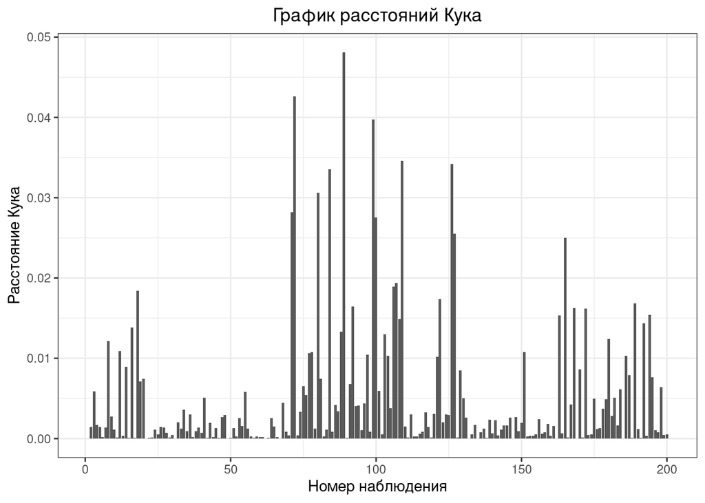

```r
ggplot(mod_diag, aes(x = 1:nrow(mod_diag), y = .cooksd)) +
  geom_bar(stat = 'identity') +
  xlab('Номер наблюдения') +
  ylab('Расстояние Кука') +
  ggtitle('График расстояний Кука') +
  theme(plot.title = element_text(hjust = 0.5))
```

Графики остатков выглядят не очень хорошо. Довольно много наблюдений за пределами двух стандартных отклонений, плюс имеем неравномерное распределение остатков по группам. Также видим, что дисперсии в группах несколько отличаются, но так как у нас число наблюдений в группах одинаковое, то дисперсионный анализ должен быть устойчив к такому.

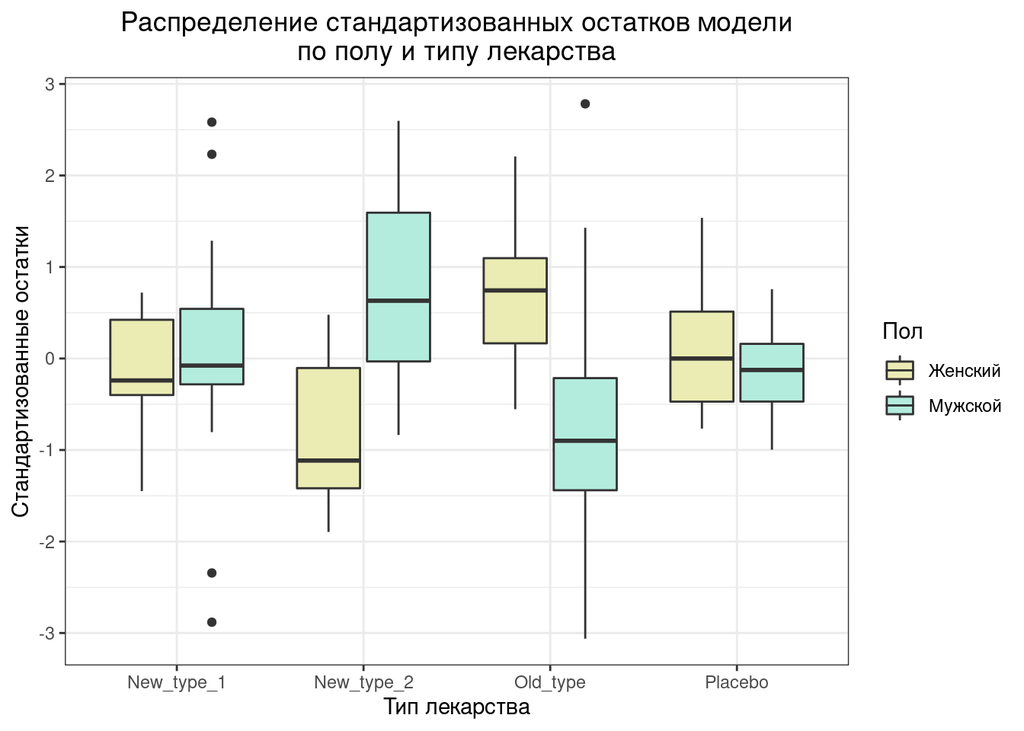

```r
ggplot(mod_diag, aes(x = drug_type, y = .stdresid)) +
  geom_boxplot(aes(fill = gender)) +
  scale_fill_manual(values = c('female' = '#EBECB3',
                               'male' = '#B3ECDD'),
                    name = "Пол", labels = c('Женский', 'Мужской')) +
  theme(plot.title = element_text(hjust = 0.5)) +
  xlab('Тип лекарства') +
  ylab('Стандартизованные остатки') +
  ggtitle('Распределение стандартизованных остатков модели\nпо полу и типу лекарства')
```

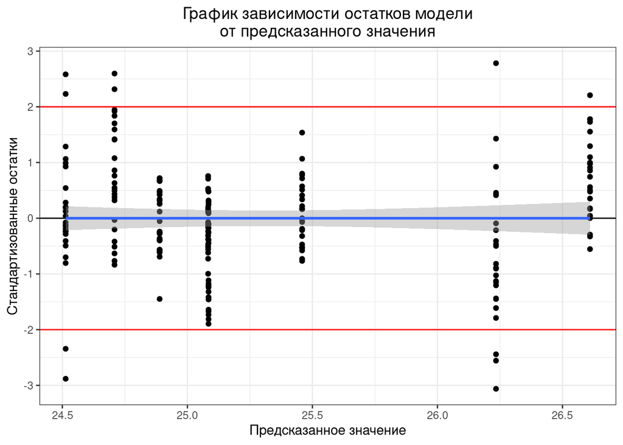

```r
ggplot(data = mod_diag, aes(x = .fitted, y = .stdresid)) +
  geom_point() +
  geom_hline(yintercept = 0) +
  geom_smooth(method = "lm") +
  geom_hline(yintercept = 2, color = "red") +
  geom_hline(yintercept = -2, color = "red") +
  xlab('Предсказанное значение') +
  ylab('Стандартизованные остатки') +
  ggtitle('График зависимости остатков модели\nот предсказанного значения') +
  theme(plot.title = element_text(hjust = 0.5))
```

В целом распределение остатков значимо не отличается от нормального.

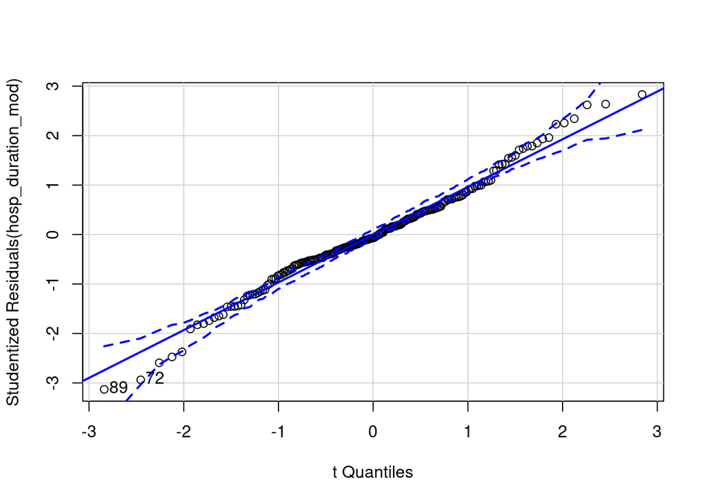

```
## [1] 72 89
```

```r
qqPlot(hosp_duration_mod)
```

```r
shapiro.test(mod_diag$.resid)
```

```
##
##  Shapiro-Wilk normality test
##
## data:  mod_diag$.resid
## W = 0.98691, p-value = 0.06186
```

## 3.3 Модель со взаимодействием предикторов

Исходя из графиков остатков модели, а также от распределения числа дней в госпитале в зависимости от пола и лекарства, можно предположить, что мы что-то не учитываем в нашем модели. Самое время попробовать добавить в нее взаимодействие предикторов.

```r
inter_model <- lm(days_in_hospital ~ gender * drug_type, data = drug_data)
av_inter_model <- Anova(mod = inter_model)
av_inter_model
```

```
## Anova Table (Type II tests)
##
## Response: days_in_hospital
##                   Sum Sq  Df F value    Pr(>F)
## gender              7.06   1  0.5491   0.45961
## drug_type          88.97   3  2.3049   0.07818 .
## gender:drug_type  939.40   3 24.3384 2.158e-13 ***
## Residuals        2470.25 192
## ---
## Signif. codes:  0 '***' 0.001 '**' 0.01 '*' 0.05 '.' 0.1 ' ' 1
```

Видим, что взаимодействие предикторов оказывает значимое влияние на зависимую переменную.

Снова проведем диагностику полученной модели

```r
inter_mod_diag <- fortify(inter_model)
```

График расстояний Кука снова выглядит нормально.

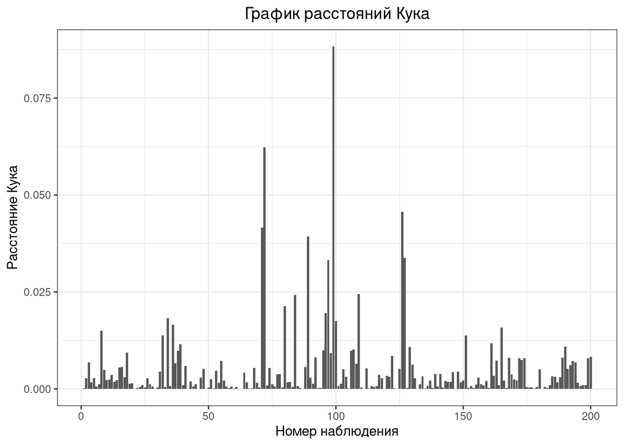

```r
ggplot(inter_mod_diag, aes(x = 1:nrow(mod_diag), y = .cooksd)) +
  geom_bar(stat = 'identity') +
  xlab('Номер наблюдения') +
  ylab('Расстояние Кука') +
  ggtitle('График расстояний Кука') +
  theme(plot.title = element_text(hjust = 0.5))
```

А вот график остатков стал выглядеть гораздо лучше: меньше наблюдений за предлелами двух стандартных отклонений, а также распределение остатков по группам примерно одинаковое.

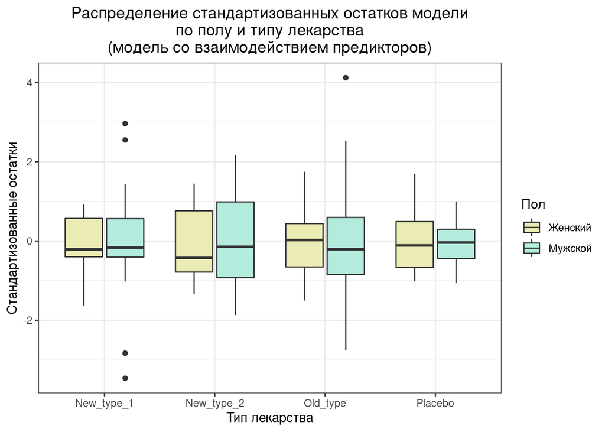

```r
ggplot(inter_mod_diag, aes(x = drug_type, y = .stdresid)) +
  geom_boxplot(aes(fill = gender)) +
  scale_fill_manual(values = c('female' = '#EBECB3',
                               'male' = '#B3ECDD'),
                    name = "Пол", labels = c('Женский', 'Мужской')) +
  theme(plot.title = element_text(hjust = 0.5)) +
  xlab('Тип лекарства') +
  ylab('Стандартизованные остатки') +
  ggtitle('Распределение стандартизованных остатков модели\nпо полу и типу лекарства\n(модель со взаимодействием предикторов)')
```

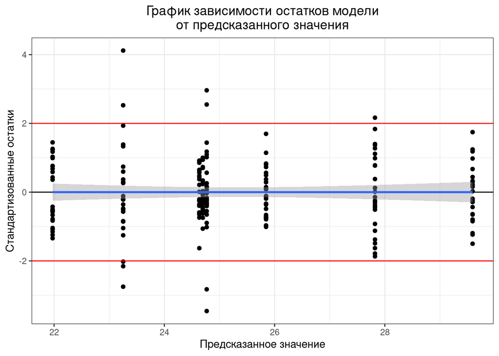

```r
ggplot(data = inter_mod_diag, aes(x = .fitted, y = .stdresid)) +
  geom_point() +
  geom_hline(yintercept = 0) +
  geom_smooth(method = "lm") +
  geom_hline(yintercept = 2, color = "red") +
  geom_hline(yintercept = -2, color = "red") +
  xlab('Предсказанное значение') +
  ylab('Стандартизованные остатки') +
  ggtitle('График зависимости остатков модели\nот предсказанного значения') +
  theme(plot.title = element_text(hjust = 0.5))
```

Видим, что в общем-то нельзя сказать, что распределение остатков не отличатся от нормального, но в данном случае это снова не критично в виду устойчивости дисперсионного анализа.

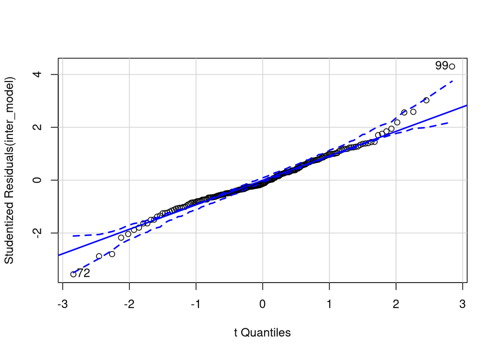

```
## [1] 72 99
```

```r
qqPlot(inter_model)
```

```r
shapiro.test(inter_mod_diag$.resid)
```

```
##
##  Shapiro-Wilk normality test
##
## data:  inter_mod_diag$.resid
## W = 0.97686, p-value = 0.002181
```

## 3.4 Интерпретация результатов

```
## Anova Table (Type II tests)
##
## Response: days_in_hospital
##                   Sum Sq  Df F value    Pr(>F)
## gender              7.06   1  0.5491   0.45961
## drug_type          88.97   3  2.3049   0.07818 .
## gender:drug_type  939.40   3 24.3384 2.158e-13 ***
## Residuals        2470.25 192
## ---
## Signif. codes:  0 '***' 0.001 '**' 0.01 '*' 0.05 '.' 0.1 ' ' 1
```

В модели оказалось значимо взаимодействие предикторов. Сочетания таких факторов, как пол и лекарство, значимо влияет на среднее количество дней, проведенных человеком в госпитале **(F = 24.3384, p_value $\approx$ 0, $df_1$ = 3, $df_2$ = 192)**

## 3.5 Пост-хок тесты

Дисперсионный анализ говорит нам только, влияет ли фактор в целом. Но не говорит, какие именно группы различаются. Чтобы это узнать необходимо сделать пост-хок тесты. Пост-хок тесты — серия попарных сравнений средних значений в группах **после того, как выявлено значимое влияние фактора.** От обычных попарных сравнений они отличаются тем, что учитывают число сравнений и величину различий между средними.

В данной работе я буду использовать пост-хок тест Тьюки.

```r
drug_data$Condition <- as.factor(paste(drug_data$gender, drug_data$drug_type, sep = '_'))
inter_fit <- lm(days_in_hospital ~ Condition - 1, data = drug_data)


res_tukey <- glht(inter_fit, linfct = mcp(Condition = 'Tukey'))
summary(res_tukey)
```

```
##
##   Simultaneous Tests for General Linear Hypotheses
##
## Multiple Comparisons of Means: Tukey Contrasts
##
##
## Fit: lm(formula = days_in_hospital ~ Condition - 1, data = drug_data)
##
## Linear Hypotheses:
##                                            Estimate Std. Error t value Pr(>|t|)
## female_New_type_2 - female_New_type_1 == 0 -2.66186    1.01453  -2.624   0.1541
## female_Old_type - female_New_type_1 == 0    4.95722    1.01453   4.886    <0.01
## female_Placebo - female_New_type_1 == 0     1.21043    1.01453   1.193   0.9331
## male_New_type_1 - female_New_type_1 == 0    0.13393    1.01453   0.132   1.0000
## male_New_type_2 - female_New_type_1 == 0    3.18670    1.01453   3.141   0.0404
## male_Old_type - female_New_type_1 == 0     -1.38133    1.01453  -1.362   0.8735
## male_Placebo - female_New_type_1 == 0       0.06298    1.01453   0.062   1.0000
## female_Old_type - female_New_type_2 == 0    7.61908    1.01453   7.510    <0.01
## female_Placebo - female_New_type_2 == 0     3.87229    1.01453   3.817    <0.01
## male_New_type_1 - female_New_type_2 == 0    2.79580    1.01453   2.756   0.1126
## male_New_type_2 - female_New_type_2 == 0    5.84856    1.01453   5.765    <0.01
## male_Old_type - female_New_type_2 == 0      1.28053    1.01453   1.262   0.9115
## male_Placebo - female_New_type_2 == 0       2.72484    1.01453   2.686   0.1334
## female_Placebo - female_Old_type == 0      -3.74679    1.01453  -3.693    <0.01
## male_New_type_1 - female_Old_type == 0     -4.82328    1.01453  -4.754    <0.01
## male_New_type_2 - female_Old_type == 0     -1.77052    1.01453  -1.745   0.6578
## male_Old_type - female_Old_type == 0       -6.33855    1.01453  -6.248    <0.01
## male_Placebo - female_Old_type == 0        -4.89424    1.01453  -4.824    <0.01
## male_New_type_1 - female_Placebo == 0      -1.07649    1.01453  -1.061   0.9639
## male_New_type_2 - female_Placebo == 0       1.97627    1.01453   1.948   0.5198
## male_Old_type - female_Placebo == 0        -2.59176    1.01453  -2.555   0.1788
## male_Placebo - female_Placebo == 0         -1.14745    1.01453  -1.131   0.9492
## male_New_type_2 - male_New_type_1 == 0      3.05276    1.01453   3.009   0.0581
## male_Old_type - male_New_type_1 == 0       -1.51526    1.01453  -1.494   0.8101
## male_Placebo - male_New_type_1 == 0        -0.07096    1.01453  -0.070   1.0000
## male_Old_type - male_New_type_2 == 0       -4.56803    1.01453  -4.503    <0.01
## male_Placebo - male_New_type_2 == 0        -3.12372    1.01453  -3.079   0.0478
## male_Placebo - male_Old_type == 0           1.44431    1.01453   1.424   0.8453
##
## female_New_type_2 - female_New_type_1 == 0
```

[output cut: 15 more lines]

```
## male_Old_type - female_Old_type == 0       ***
## male_Placebo - female_Old_type == 0        ***
## male_New_type_1 - female_Placebo == 0
## male_New_type_2 - female_Placebo == 0
## male_Old_type - female_Placebo == 0
## male_Placebo - female_Placebo == 0
## male_New_type_2 - male_New_type_1 == 0     .
## male_Old_type - male_New_type_1 == 0
## male_Placebo - male_New_type_1 == 0
## male_Old_type - male_New_type_2 == 0       ***
## male_Placebo - male_New_type_2 == 0        *
## male_Placebo - male_Old_type == 0
## ---
## Signif. codes:  0 '***' 0.001 '**' 0.01 '*' 0.05 '.' 0.1 ' ' 1
## (Adjusted p values reported -- single-step method)
```

В данном случае видим, что найдены различия между большим числом групп. Основные результаты, которые мы можем получить здесь состоят в том, что нужно подбирать правильное лекарство для пациента в зависимости от его пола для ускорения его выздоровления (в некоторых случаях неверно подобранное лекарство может даже замедлять процесс восстановления).

Визуализируем результаты пост-хок теста для лучшего их восприятия.

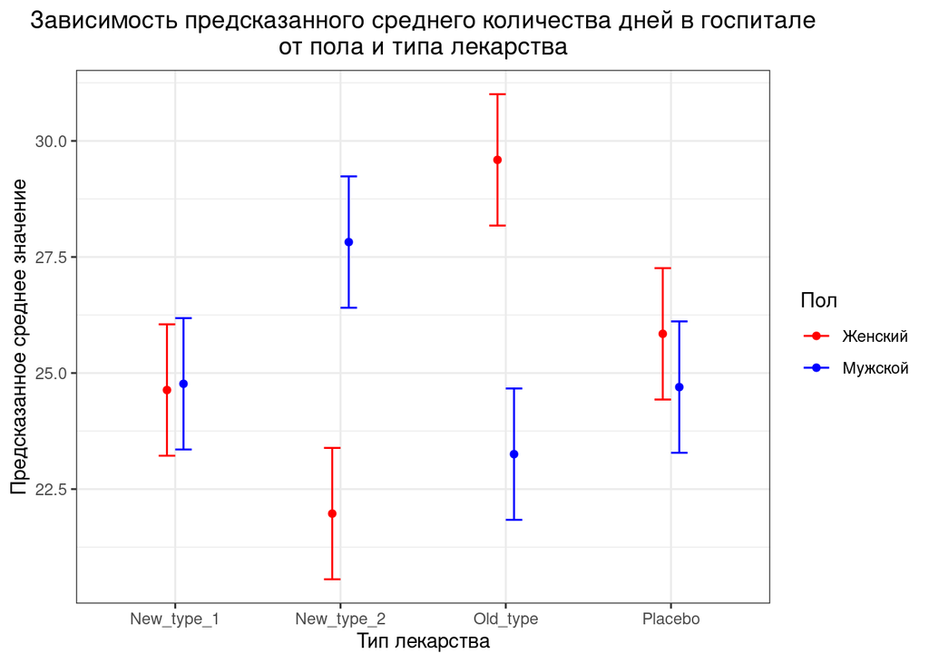

```r
data <-  expand.grid(gender = levels(drug_data$gender),
                   drug_type = levels(drug_data$drug_type))
data <- data.frame(data,
                   predict(inter_model, newdata = data, interval = 'confidence'))
pos <- position_dodge(width = 0.2)
gg_linep <- ggplot(data, aes(x = drug_type, y = fit,
                             ymin = lwr, ymax = upr,
                             color = gender)) +
  geom_point(position = pos) +
  geom_errorbar(position = pos, width = 0.2) +
  scale_color_manual(values = c('female' = 'red',
                               'male' = 'blue'),
                    name = "Пол", labels = c('Женский', 'Мужской')) +
  theme(plot.title = element_text(hjust = 0.5)) +
  xlab('Тип лекарства') +
  ylab('Предсказанное среднее значение') +
  ggtitle('Зависимость предсказанного среднего количества дней в госпитале\nот пола и типа лекарства')
gg_linep
```